# Math 300 NTI Lesson 29

Permutation Tests

Professor Bradley Warner

July, 2022

## Objectives

1. Explain the permutation test and compare and contrast it with a bootstrap distribution.
2. Generate and interpret visualizations for data with two categorical variables.

## Reading

[Chapter 9 - 9.1](https://moderndive.com/9-hypothesis-testing.html)

## Lesson

*Remember that you will be running this more like a lab than a lecture. You want them using `R` and answering questions. Have them open the notes rmd and work through it together.*

There are no learning checks for this lesson.

- This is a key idea for the instructors from the reading: *The same can be said for confidence intervals. There was one general framework that applies to all confidence intervals and the `infer` package was designed around this framework. While the specifics may change slightly for different types of confidence intervals, the general framework stays the same. We believe that this approach is much better for long-term learning than focusing on specific details for specific confidence intervals using theory-based approaches. As you’ll now see, we prefer this general framework for hypothesis tests as well.*
- *Computer-based methods using randomization, simulation, and bootstrapping have much fewer restrictions.*
- We are going to bring ideas from earlier in the course to start our work on hypothesis testing.

### Libraries

```r
library(tidyverse)
library(infer)
library(moderndive)
library(nycflights13)
library(ggplot2movies)
```

### Promotions problem

The reading discusses the research question: “Does gender affect promotions at a bank?”. Similar to the yawning experiment, we have two categorical variables and so many of the tools will be the same.

### Summarizing data

Let’s start by exploring the data.

```r
promotions %>%
  group_by(decision, gender) %>%
  tally()
```

```
## # A tibble: 4 x 3
## # Groups:   decision [2]
##   decision gender     n
##   <fct>    <fct>  <int>
## 1 not      male       3
## 2 not      female    10
## 3 promoted male      21
## 4 promoted female    14
```

- What is the impact of changing the order of the variables in the `group_by()` function and which is better for a decision maker based on the research question?

**Answer:** The first variable is used as the first level of grouping. We think it is better to sort first on gender then on decision. It makes it easier to compare male and females.

```r
promotions %>%
  group_by(gender, decision) %>%
  tally()
```

```
## # A tibble: 4 x 3
## # Groups:   gender [2]
##   gender decision     n
##   <fct>  <fct>    <int>
## 1 male   not          3
## 2 male   promoted    21
## 3 female not         10
## 4 female promoted    14
```

We think this is the best summary.

```r
promotions %>%
  group_by(gender, decision) %>%
  tally() %>%
  mutate(perc = round(n / sum(n)*100,2))
```

```
## # A tibble: 4 x 4
## # Groups:   gender [2]
##   gender decision     n  perc
##   <fct>  <fct>    <int> <dbl>
## 1 male   not          3  12.5
## 2 male   promoted    21  87.5
## 3 female not         10  41.7
## 4 female promoted    14  58.3
```

#### Visulaizing data

- Create a barchart to summarize the data.

**Answer:** We think this is the best plot for data.

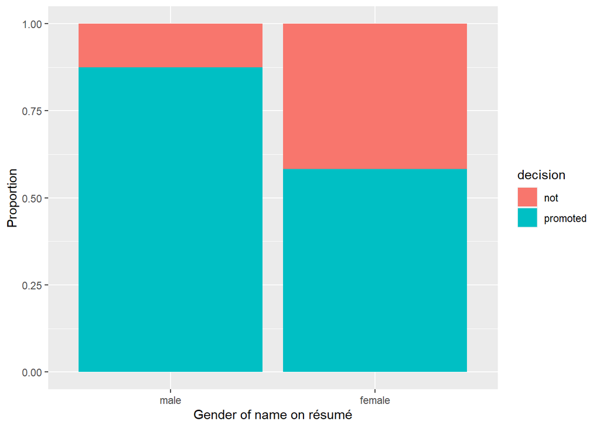

```r
ggplot(promotions, aes(x = gender, fill = decision)) +
  geom_bar(position="fill") +
  labs(x = "Gender of name on résumé",y="Proportion")
```

#### Bootstrap confidence interval

- Find a 90% bootstrap confidence interval the difference in proportions. Interpret this confidence interval.

**Answer:**

Generate the bootstrap distribution

```r
set.seed(612)
bootstrap_distribution_promotions <- promotions %>%
  specify(formula = decision ~ gender, success = "promoted") %>%
  generate(reps = 1000, type = "bootstrap") %>%
  calculate(stat = "diff in props", order = c("male", "female"))
```

```r
head(bootstrap_distribution_promotions)
```

```
## Response: decision (factor)
## Explanatory: gender (factor)
## # A tibble: 6 x 2
##   replicate  stat
##       <int> <dbl>
## 1         1 0.230
## 2         2 0.189
## 3         3 0.402
## 4         4 0.235
## 5         5 0.393
## 6         6 0.119
```

- Visualize the results.

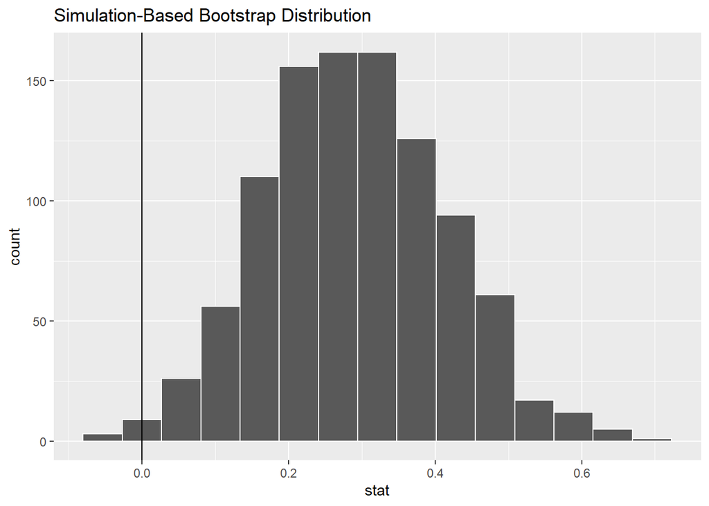

```r
visualize(bootstrap_distribution_promotions) +
  geom_vline(xintercept = 0)
```

```r
get_ci(level=0.90,bootstrap_distribution_promotions,type="percentile")
```

```
## # A tibble: 1 x 2
##   lower_ci upper_ci
##      <dbl>    <dbl>
## 1   0.0943    0.497
```

We are 90% confidence the true difference in proportion of males promoted and females promoted is between 0.094 and 0.497. Based on this information, we would conclude that the data supports the idea that female are promoted at a different rate than males.

### Permutation test

We want to answer the same research question but we approach it differently. The key idea is that we assume there is no difference between males and females and then find the sampling distribution under this assumption. For our problem this implies that the column `gender` is irrelevant. Thus we could arbitrarily change, shuffle, these labels. That is what we will do.

Here is the first six rows of the original data.

```r
head(promotions)
```

```
## # A tibble: 6 x 3
##      id decision gender
##   <int> <fct>    <fct>
## 1     1 promoted male
## 2     2 promoted male
## 3     3 promoted male
## 4     4 promoted male
## 5     5 promoted male
## 6     6 promoted male
```

Let’s shuffle the `gender` column.

```r
set.seed(272)
promotions_mod <- promotions %>%
  mutate(shuffled=sample(gender))
```

```r
head(promotions_mod)
```

```
## # A tibble: 6 x 4
##      id decision gender shuffled
##   <int> <fct>    <fct>  <fct>
## 1     1 promoted male   female
## 2     2 promoted male   male
## 3     3 promoted male   male
## 4     4 promoted male   female
## 5     5 promoted male   male
## 6     6 promoted male   female
```

Notice that the number of males and females has not changed since by default we sampled without replacement. However, the number promoted for each gender level has changed.

```r
promotions_mod %>%
  group_by(shuffled, decision) %>%
  tally()  %>%
  mutate(perc = round(n / sum(n)*100,2))
```

```
## # A tibble: 4 x 4
## # Groups:   shuffled [2]
##   shuffled decision     n  perc
##   <fct>    <fct>    <int> <dbl>
## 1 male     not          6  25
## 2 male     promoted    18  75
## 3 female   not          7  29.2
## 4 female   promoted    17  70.8
```

This is the heart of the permutation test. We shuffle the gender labels repeatedly and find the test statistic. This allows us to determine if the observed test statistic from the original sample is likely under the assumption of no difference in promotion rates for males and females.

We will be using the `infer` package to conduct the permutation test later in this chapter. But before we learn how to do this, let’s use data where students randomly shuffled the data.

Read in the data.

```r
gender_promotions_shuffles <- read_csv("ch9_gender_promotions_shuffles.csv")
```

Look at the first 6 rows.

```r
head(gender_promotions_shuffles)
```

```
## # A tibble: 6 x 18
##      id decision `Cassandra, Nox` `Priya, Jenny, Eindra` `Maddie, Grace, Steph~`
##   <dbl> <chr>    <chr>            <chr>                  <chr>
## 1     1 not      m                m                      m
## 2     2 not      m                m                      f
## 3     3 not      m                f                      m
## 4     4 not      f                f                      f
## 5     5 not      f                m                      f
## 6     6 not      m                m                      m
## # ... with 13 more variables: `Dahlia, Sarah` <chr>,
## #   `Claire, Cindy, Danna` <chr>, `Karen, Josephine` <chr>, `Noa, Maia` <chr>,
## #   `Eunice, Tina` <chr>, `Sofia, Tim` <chr>, `Faith, Hafsa` <chr>,
## #   `Taylor, Logan` <chr>, `Daniel, Ella` <chr>, `Morgan, Arianna` <chr>,
## #   `Beatrix, Serena` <chr>, `Glenda, Naomi, Erin` <chr>, `Sunshine, Min` <chr>
```

We need to do some data wrangling to get it into **tidy** data. You are not accountable to these steps but we want to demonstrate data wrangling. The `infer` package is going to make this easier for us.

Get the data in tidy form.

```r
shuffled_data_tidy  <- gender_promotions_shuffles %>%
  pivot_longer(cols=-c("id", "decision"),
               names_to = "team", values_to = "gender") %>%
  mutate(replicate = rep(1:16, times = 48))
```

Check that we did this correctly.

```r
head(shuffled_data_tidy,n=17)
```

```
## # A tibble: 17 x 5
##       id decision team                     gender replicate
##    <dbl> <chr>    <chr>                    <chr>      <int>
##  1     1 not      Cassandra, Nox           m              1
##  2     1 not      Priya, Jenny, Eindra     m              2
##  3     1 not      Maddie, Grace, Stephanie m              3
##  4     1 not      Dahlia, Sarah            m              4
##  5     1 not      Claire, Cindy, Danna     m              5
##  6     1 not      Karen, Josephine         f              6
##  7     1 not      Noa, Maia                m              7
##  8     1 not      Eunice, Tina             f              8
##  9     1 not      Sofia, Tim               m              9
## 10     1 not      Faith, Hafsa             f             10
## 11     1 not      Taylor, Logan            m             11
## 12     1 not      Daniel, Ella             f             12
## 13     1 not      Morgan, Arianna          m             13
## 14     1 not      Beatrix, Serena          m             14
## 15     1 not      Glenda, Naomi, Erin      m             15
## 16     1 not      Sunshine, Min            m             16
## 17     2 not      Cassandra, Nox           m              1
```

And another check.

```r
shuffled_data_tidy %>% group_by(replicate) %>% count(gender)
```

```
## # A tibble: 32 x 3
## # Groups:   replicate [16]
##    replicate gender     n
##        <int> <chr>  <int>
##  1         1 f         24
##  2         1 m         24
##  3         2 f         24
##  4         2 m         24
##  5         3 f         24
##  6         3 m         24
##  7         4 f         24
##  8         4 m         24
##  9         5 f         24
## 10         5 m         24
## # ... with 22 more rows
```

Let’s find the difference in proportions between male and females.

```r
test_stats <- shuffled_data_tidy %>%
  group_by(replicate) %>%
  count(gender, decision) %>%
  filter(decision == "promoted") %>%
  mutate(prop = n / 24) %>%
  select(replicate, gender, prop) %>%
  pivot_wider(names_from="gender",values_from = prop) %>%
  mutate(stat = m - f)
```

```r
head(test_stats)
```

```
## # A tibble: 6 x 4
## # Groups:   replicate [6]
##   replicate     f     m    stat
##       <int> <dbl> <dbl>   <dbl>
## 1         1 0.792 0.667 -0.125
## 2         2 0.708 0.75   0.0417
## 3         3 0.708 0.75   0.0417
## 4         4 0.75  0.708 -0.0417
## 5         5 0.708 0.75   0.0417
## 6         6 0.708 0.75   0.0417
```

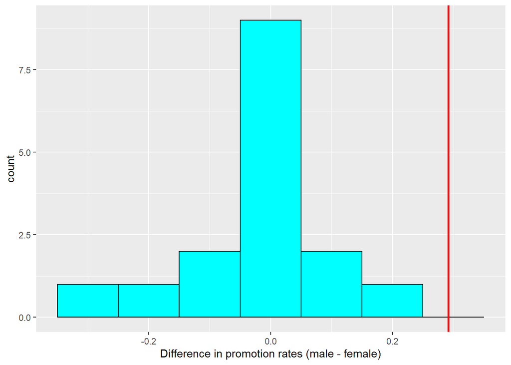

```r
ggplot(data = test_stats, aes(x = stat)) +
  geom_histogram(binwidth = 0.1, fill = "cyan", color = "black") +
  geom_vline(xintercept = (21/24 -14/24 ), color = "red", size = 1) +
  labs(x = "Difference in promotion rates (male - female)")
```

- Interpret this histogram

**Answer:** If there were no difference in proportion of promotions for males and females, it is highly unlikely we would get the observed difference.

- Compare the permutation test sampling distribution to the bootstrap.

**Answer:** The bootstrap and permutation test sampling distributions look similar except where they are centered. The bootstrap is centered on the observed sample statistics and the permutation is centered on the hypothesized value of zero.

## Documenting software

- File creation date: 2022-07-07
- R version 4.1.3 (2022-03-10)
- `tidyverse` package version: 1.3.1
- `moderndive` package version: 0.5.4
- `infer` package version: 1.0.2
- `nycflights13` package version: 1.0.2
- `ggplot2movies` package version: 0.0.1